# Final Analyses - Experiment 1

In this notebook, I will provide final analyses for experiment 1 in the paper “Of Primary Importance? Motivation Drives Resource Allocation Across Concurrent Tasks During Multimedia Processing.”

In this experiment, participants played three ten-minute rounds of *Asteroid Impact*. One of these rounds contained a cognitive load manipulation (a 1-back memory maintenance task) and one of these rounds contained a perceptual load manipulation (a haze overlay). Perceptual load findings are reported elsewhere, and as such will not be analyzed here [removed for anonymous review]. The third round contained neither the perceptual load nor the cognitive load manipulation, but was otherwise equivalent in gameplay mechanics. All rounds were presented in randomized order.

During the course of gameplay, participants also responded to a secondary task. In this task, participants pressed “x” upon seeing a purple square appear on screen and pressed “z” upon seeing a blue triangle appear on screen. The square was associated with a much higher point reward than was the triangle, although both appeared with equal frequency.

More information regarding the protocol for this experiment can be found [here][https://osf.io/49673/?view_only=efc95fca03374c8dbdf75807be5ecb41]

## Hypotheses

- **H1**: Cognitive load should result in reduced STRT’s and reduced performance on a primary task.
- **H2**: High-reward STRT probes should be responded to faster than low reward STRT probes.
- **H3**: Reward should interact with cognitive load such that at high load the gap in response time between high-reward and low-reward distractors should increase.

## Setup

First I need to import some packages and get the data ingested. These data have already been pre-processed. For more details on the pre-processing steps that were applied to each experiment, see the OSF link above.

```r
setwd("/home/jtf/projects/inprogress/cogperc/paper/")

library(tidyverse)
library(ggthemes)
library(jtools)
library(lme4)
data <- read_csv("exp1/data/fulldata_exp1.csv")
```

I should do a few descriptives and plots to make sure that everything is looking good to go.

```r
#Number of subjects
length(unique(data$sub_id))
```

```
## [1] 123
```

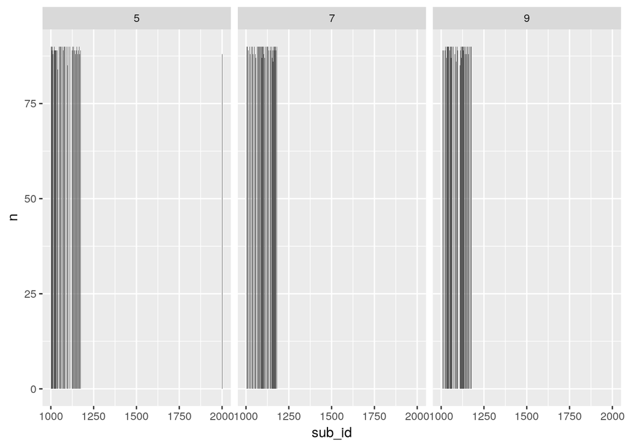

```r
# Number of reaction prompts per subject and condition

plt_data = data %>% group_by(sub_id, step_number) %>% summarize(n = first(n))
ggplot(plt_data, aes(x = sub_id, y = n)) + geom_bar(stat="identity") + facet_wrap(~ step_number)
```

```r
# Mean and SD of reaction prompts
mean(data$reaction_prompt_millis)
```

```
## [1] 1404.921
```

```r
sd(data$reaction_prompt_millis)
```

```
## [1] 1558.136
```

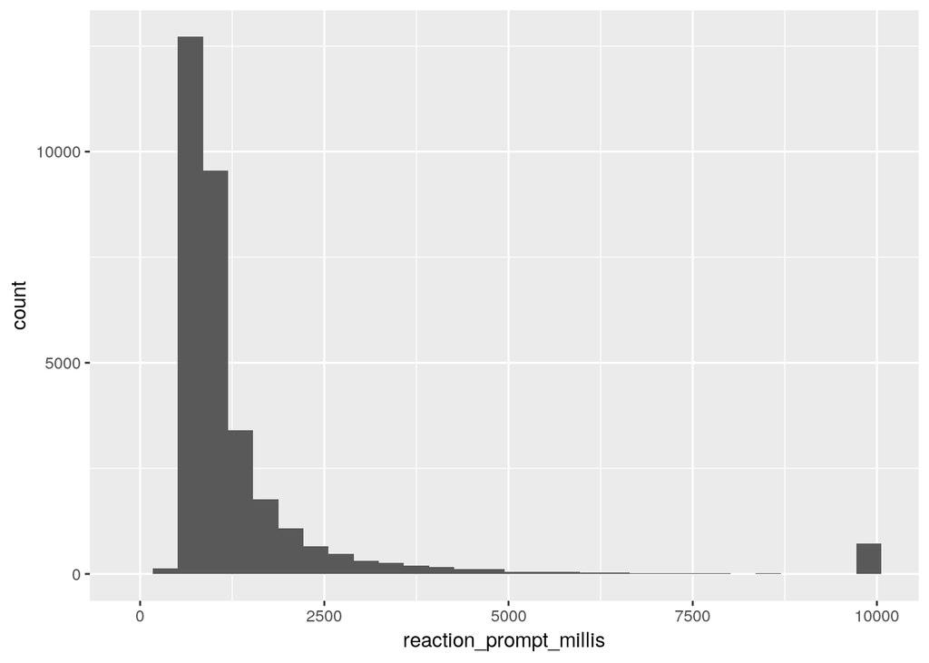

```r
# Distribution of reaction prompts

ggplot(data) + geom_histogram(aes(x = reaction_prompt_millis))
```

Everything looks pretty standard. Let’s log transform the RTs for the analyses so that they will be more normally distributed.

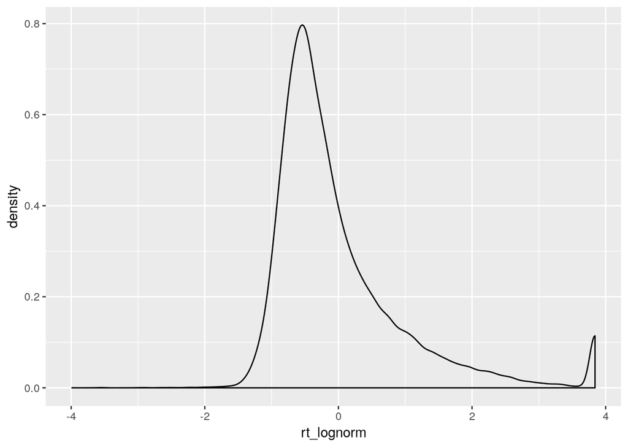

```r
data <- data %>% mutate(rt_log = log(reaction_prompt_millis), rt_lognorm = scale(rt_log))
ggplot(data) + geom_density(aes(x = rt_lognorm))
```

The first thing that I need to do is get rid of the perceptual load condition since its not of interest to these analyses. I’ll also recode cognitive load and reward into effect coding.

```r
data_filt <- data %>% filter(conditionstep != 2) %>%
  mutate(cogload = recode(cogload, "1" = -1, "2" = 1),
         reward = recode(react_reward, "low" = -1, "high" = 1))
```

## Main Effects

Since everything here is repeated measures, we’ll do mixed-effects analyses using the `lmer` function from the `lme4` package. To extract the confidence intervals and p-values we will user `lmerTest`. The first thing that we need to do is a simple t-test of reaction times between the high and low cognitive load conditions and between the high and low reward conditions.

## Main effect of cognitive load

```r
require(lmerTest)
lmm1 <- lmer(rt_lognorm ~ cogload + (1|sub_id) + (1|cogload:sub_id), data=data_filt)
summary(lmm1)
```

```
## Linear mixed model fit by REML. t-tests use Satterthwaite's method [
## lmerModLmerTest]
## Formula: rt_lognorm ~ cogload + (1 | sub_id) + (1 | cogload:sub_id)
##    Data: data_filt
##
## REML criterion at convergence: 58093.4
##
## Scaled residuals:
##     Min      1Q  Median      3Q     Max
## -4.5662 -0.5869 -0.2024  0.3453  4.2601
##
## Random effects:
##  Groups         Name        Variance Std.Dev.
##  cogload:sub_id (Intercept) 0.08018  0.2832
##  sub_id         (Intercept) 0.11294  0.3361
##  Residual                   0.86509  0.9301
## Number of obs: 21311, groups:  cogload:sub_id, 246; sub_id, 123
##
## Fixed effects:
##              Estimate Std. Error        df t value Pr(>|t|)
## (Intercept)   0.05557    0.03585 122.07500    1.55    0.124
## cogload       0.22264    0.01915 122.54181   11.63   <2e-16 ***
## ---
## Signif. codes:  0 '***' 0.001 '**' 0.01 '*' 0.05 '.' 0.1 ' ' 1
##
## Correlation of Fixed Effects:
##         (Intr)
## cogload 0.000
```

```r
anova(lmm1)
```

```
## Type III Analysis of Variance Table with Satterthwaite's method
##         Sum Sq Mean Sq NumDF  DenDF F value    Pr(>F)
## cogload 116.94  116.94     1 122.54  135.17 < 2.2e-16 ***
## ---
## Signif. codes:  0 '***' 0.001 '**' 0.01 '*' 0.05 '.' 0.1 ' ' 1
```

```r
detach(package:lmerTest)
```

```r
test <- data_filt %>% group_by(cogload) %>% summarize(mean = mean(rt_lognorm))
d <- test[['mean']][2] - test[['mean']][1] / sigma(lmm1)
```

Effect size is 0.4520055

## Main effect of reward

```r
require(lmerTest)
lmm1 <- lmer(rt_lognorm ~ reward + (1|sub_id) + (1|reward:sub_id), data=data_filt)
summary(lmm1)
```

```
## Linear mixed model fit by REML. t-tests use Satterthwaite's method [
## lmerModLmerTest]
## Formula: rt_lognorm ~ reward + (1 | sub_id) + (1 | reward:sub_id)
##    Data: data_filt
##
## REML criterion at convergence: 59242.7
##
## Scaled residuals:
##     Min      1Q  Median      3Q     Max
## -4.6627 -0.6063 -0.2353  0.3350  4.3650
##
## Random effects:
##  Groups        Name        Variance Std.Dev.
##  reward:sub_id (Intercept) 0.02191  0.1480
##  sub_id        (Intercept) 0.14085  0.3753
##  Residual                  0.91944  0.9589
## Number of obs: 21311, groups:  reward:sub_id, 246; sub_id, 123
##
## Fixed effects:
##               Estimate Std. Error         df t value Pr(>|t|)
## (Intercept)   0.002054   0.035819 122.459769   0.057    0.954
## reward       -0.167799   0.011742 123.966525 -14.291   <2e-16 ***
## ---
## Signif. codes:  0 '***' 0.001 '**' 0.01 '*' 0.05 '.' 0.1 ' ' 1
##
## Correlation of Fixed Effects:
##        (Intr)
## reward 0.039
```

```r
anova(lmm1)
```

```
## Type III Analysis of Variance Table with Satterthwaite's method
##        Sum Sq Mean Sq NumDF  DenDF F value    Pr(>F)
## reward 187.78  187.78     1 123.97  204.23 < 2.2e-16 ***
## ---
## Signif. codes:  0 '***' 0.001 '**' 0.01 '*' 0.05 '.' 0.1 ' ' 1
```

```r
detach(package:lmerTest)
```

Plots